# Análisis estadístico de datos de Microbioma con R

Capítulo 8: Análisis univariado de comunidades

Equipo 4

Andrés Arredondo Cruz (andresabstract@gmail.com)

Adriana Haydé Contreras Peruyero (haydeeperuyero@gmail.com)

David Alberto García Estrada (david.garcia.e@cinvestav.mx)

2022-10-02

# Introducción

Dividimos el estudio de la composición de las comunidades microbianas en dos grandes componentes:

(a)Evaluación de hipótesis sobre diversidad taxonómica, OTU y Taxones.  
(b) Análisis de diferencias entre grupos.

El primer componente pertenece principalmente a análisis univariado de comunidades. El segundo puede ser dividido en varias técnicas multivariadas, como lo son “clustering” y “ordinations”, y la evaluación de hipótesis de análisis multivariado de disimilitudes.

# Comparaciones de diversidades entre dos grupos

En nuestro estudio con ratones Vdr$-/-$, uno de los propósitos es probar la diferencia de diversidades entre dos grupos (Vdr$-/-$ y ratones de tipo salvaje) en sitios fecales y cecales. Aquí ilustraremos el análisis de la comunidad univariante, y compararemos la diversidad de Shannon (calculada anteriormente en el Cap. 6 en las muestras fecales) usando varios estadísticos de prueba.

## Prueba $t$ de Welch para dos muestras

El estadístico $t$ fue introducido en 1908 por William Sealy Gosset. Una prueba $t$ de dos muestras se utiliza para probar que las medias de dos poblaciones son iguales. Se aplica más comúnmente cuando el estadístico de prueba sigue una distribución normal. Si los dos grupos tienen la misma varianza, el estadístico $t$ se puede calcular de la siguiente manera:

$$t=\frac{\bar X_1 - \bar X_2}{^{Sp} \sqrt{\frac{1}{n_1}+\frac{1}{n_2}}}$$
donde, $s_p = \sqrt{\frac{(n-1)s_1^2+(n_2-1)s_2^2}{n_1+n_2-2}}$ es un estimador de desviación estándar de las dos muestras. La prueba $t$ de Welch o la prueba $t$ de varianzas desiguales es una adaptación de la prueba $t$. El estadístico de la prueba $t$ de Welch está dado por:

$$t\ =\
\frac{\bar{X}_1-\bar{X}_2}{s_{\bar{\Delta}}},$$

donde $s_{\bar{\Delta}}=\sqrt{\frac{s_{1}^2}{n_1}+\frac{s_2^2}{n_2}}$; $s_1^2$ y $s_2^2$ son los estimadores imparciales de la varianza de las muestras 1 y 2, respectivamente. Cuando las dos muestras tienen varianzas desiguales y tamaños de muestra desiguales, la prueba $t$ de Welch se considera más confiable.

Por lo tanto, aquí usamos la prueba $t$ de Welch para nuestros datos de ratón Vdr$-/-$.

Primero, cargamos y calculamos la transpuesta del conjunto de datos:

```r
# IMPORTANTE
# Ajusta el directorio de trabajo según tu PC
# Mostramos directorio actual
getwd()
```

```
## [1] "D:/Users/hayde/Documents/R_sites/Equipo4/Chapter8"
```

```r
# Si es necesario, cambiar la ruta donde están los archivos almacenados.
# "." significa el directorio actual.
workingDir <-  "."
setwd(workingDir)
```

```r
abund_table <-  read.csv(paste0(workingDir,"/data/VdrGenusCounts.csv"),
                         row.names=1, check.names=FALSE)
abund_table <- t(abund_table)
```

Para incorporar la información del grupo del conjunto de datos directamente a la comparación, necesitamos administrar los datos. En el conjunto de datos, la información del ID de la muestra y el grupo están en una franja de caracteres. Primero los extraemos de allí.

```r
grouping <- data.frame(row.names = rownames(abund_table),
                       t(as.data.frame(strsplit(rownames(abund_table),"_"))))
grouping$Location <- with(grouping, ifelse(X3%in%"drySt-28F", "Fecal", "Cecal"))
grouping$Group <- with(grouping,ifelse(as.factor(X2)%in% c(11,12,13,14,15),
                                       c("Vdr-/-"), c("WT")))
grouping <- grouping[,c(4,5)]
grouping
```

```
##                Location  Group
## 5_15_drySt-28F    Fecal Vdr-/-
## 20_12_CeSt-28F    Cecal Vdr-/-
## 1_11_drySt-28F    Fecal Vdr-/-
## 2_12_drySt-28F    Fecal Vdr-/-
## 3_13_drySt-28F    Fecal Vdr-/-
## 4_14_drySt-28F    Fecal Vdr-/-
## 7_22_drySt-28F    Fecal     WT
## 8_23_drySt-28F    Fecal     WT
## 9_24_drySt-28F    Fecal     WT
## 19_11_CeSt-28F    Cecal Vdr-/-
## 21_13_CeSt-28F    Cecal Vdr-/-
## 22_14_CeSt-28F    Cecal Vdr-/-
## 23_15_CeSt-28F    Cecal Vdr-/-
## 25_22_CeSt-28F    Cecal     WT
## 26_23_CeSt-28F    Cecal     WT
## 27_24_CeSt-28F    Cecal     WT
```

Repetimos el calculo de la diversidad de Shannon para esta tabla, igual que en el capítulo 6.

```r
library(vegan)
H<-diversity(abund_table, "shannon")
```

Luego combinamos los dataframes de la diversidad de Shannon y agrupación para crear un nuevo dataframe.

```r
#hacemos un df de la diversidad de shannon
df_H<-data.frame(sample=names(H),value=H,measure=rep("Shannon",length(H)))
#combinamos la diversidad y los dataframes agrupados para crear un nuevo df
df_G <-cbind(df_H, grouping)
rownames(df_G)<-NULL
df_G
```

```
##            sample    value measure Location  Group
## 1  5_15_drySt-28F 2.460729 Shannon    Fecal Vdr-/-
## 2  20_12_CeSt-28F 2.339725 Shannon    Cecal Vdr-/-
## 3  1_11_drySt-28F 2.228023 Shannon    Fecal Vdr-/-
## 4  2_12_drySt-28F 2.734405 Shannon    Fecal Vdr-/-
## 5  3_13_drySt-28F 2.077282 Shannon    Fecal Vdr-/-
## 6  4_14_drySt-28F 2.466830 Shannon    Fecal Vdr-/-
## 7  7_22_drySt-28F 1.777171 Shannon    Fecal     WT
## 8  8_23_drySt-28F 1.999559 Shannon    Fecal     WT
## 9  9_24_drySt-28F 1.971996 Shannon    Fecal     WT
## 10 19_11_CeSt-28F 1.344813 Shannon    Cecal Vdr-/-
## 11 21_13_CeSt-28F 2.016113 Shannon    Cecal Vdr-/-
## 12 22_14_CeSt-28F 1.955433 Shannon    Cecal Vdr-/-
## 13 23_15_CeSt-28F 1.614456 Shannon    Cecal Vdr-/-
## 14 25_22_CeSt-28F 1.958839 Shannon    Cecal     WT
## 15 26_23_CeSt-28F 2.270818 Shannon    Cecal     WT
## 16 27_24_CeSt-28F 2.002195 Shannon    Cecal     WT
```

A continuación, creamos subconjuntos de datos fecales del nuevo dataframe.

```r
Fecal_G<- subset(df_G, Location=="Fecal")
Fecal_G
```

```
##           sample    value measure Location  Group
## 1 5_15_drySt-28F 2.460729 Shannon    Fecal Vdr-/-
## 3 1_11_drySt-28F 2.228023 Shannon    Fecal Vdr-/-
## 4 2_12_drySt-28F 2.734405 Shannon    Fecal Vdr-/-
## 5 3_13_drySt-28F 2.077282 Shannon    Fecal Vdr-/-
## 6 4_14_drySt-28F 2.466830 Shannon    Fecal Vdr-/-
## 7 7_22_drySt-28F 1.777171 Shannon    Fecal     WT
## 8 8_23_drySt-28F 1.999559 Shannon    Fecal     WT
## 9 9_24_drySt-28F 1.971996 Shannon    Fecal     WT
```

Ahora, los datos están listos para el análisis estadístico. Antes de realizar la prueba de hipótesis, exploremos la distribución de los valores de diversidad de Shannon usando la función `ggplot()`.

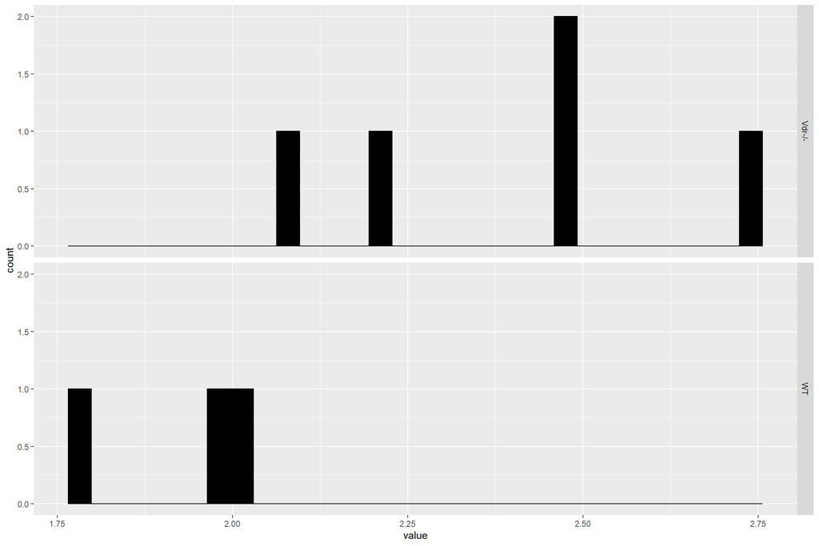

8.1 Diversidad de Shannon

```r
library(ggplot2)

#Ahora dividimos el gráfico en dos paneles usando facet_grid.
p<-ggplot(Fecal_G, aes(x=value))+
  geom_histogram(color="black", fill="black")+
  facet_grid(Group ~ .)
p
```

El paquete `plyr` se utiliza para calcular los valores promedio de la diversidad de Shannon de cada grupo.

```r
library(plyr)
#la función ddply toma input un df y arroja un df de output
mu <- ddply(Fecal_G, "Group", summarise, grp.mean=mean(value))
head(mu)
```

```
##    Group grp.mean
## 1 Vdr-/- 2.393454
## 2     WT 1.916242
```

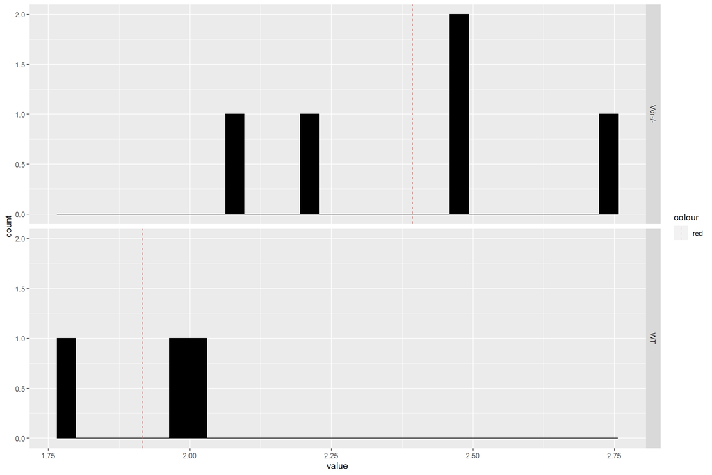

8.2 Diversidad de Shannon con líneas de media.

```r
#Agregamos las líneas de la media a la gráfica
p+geom_vline(data=mu, aes(xintercept=grp.mean, color="red"),
             linetype="dashed")
```

En el histograma anterior (Figura ‘8.2’) la eliminación de Vdr de este grupo se desplaza hacia la derecha en relación con el grupo WT (hacia valores de diversidad más altos), lo que da como resultado una mayor diversidad.

Hacemos la prueba $t$ de Welch.

```r
#Usamos la prueba t de Welch para probar la hipótesis nula
fit_t <- t.test(value ~ Group, data=Fecal_G)
fit_t
```

```
##
##  Welch Two Sample t-test
##
## data:  value by Group
## t = 3.5999, df = 5.9206, p-value = 0.01163
## alternative hypothesis: true difference in means between group Vdr-/- and group WT is not equal to 0
## 95 percent confidence interval:
##  0.1517841 0.8026392
## sample estimates:
## mean in group Vdr-/-     mean in group WT
##             2.393454             1.916242
```

Para probar la hipótesis nula de que no hay diferencia en la diversidad de Shannon, se utilizó una prueba $t$ de Welch que dio como resultado un valor de p = 0.0116305 (t = 3.5998798, df = 5.9206265). Por lo tanto, rechazamos la hipótesis nula de no diferencia a favor de la alternativa de que las diversidades de Shannon son diferentes en los dos grupos.

## La prueba de la suma de rangos de Wilcoxon

*La prueba de la suma de rangos de Wilcoxon* es equivalente a la prueba “U de Mann-Whitney” desarrollada por Mann y Whitney en 1947. Es una alternativa no paramétrica a la prueba $t$ para dos muestras que utiliza rangos de datos de dos muestras que son independientes, para probar la hipótesis nula: las dos muestras independientes provienen de poblaciones con la misma distribución (es decir, las dos poblaciones son idénticas). A diferencia de la prueba $t$, *la prueba de suma de rangos de Wilcoxon* no requiere la suposición de distribuciones normales y es casi tan eficiente como la prueba $t$. Por lo tanto, es ampliamente utilizado en el estudio del microbioma. Se necesitan tres pasos principales para realizar *la prueba de suma de rangos de Wilcoxon* para encontrar el valor de la estadística de prueba:

**Paso 1**: Asignar rangos a todas las observaciones, el valor más pequeño obtiene un rango de 1. Cuando los valores estén empatados, asignar la media de los rangos involucrados en el empate.

**Paso 2**: Sumar los rangos de cualquiera de las dos muestras. La suma de rangos en otra muestra se puede determinar ya que la suma de todos los rangos es igual a $N(N + 1)/2$, donde $N$ es el número total de observaciones.

Si las dos poblaciones de prueba tienen la misma distribución, entonces el rango $R$ tiene la media de $\mu_R=\frac{n_1(n_1+n_2+1)}{2}$ y la desviación estándar de $\sigma_R=\sqrt\frac{n_1n_2(n_1+n_2+1)}{12}$. *La prueba de la suma de rangos de Wilcoxon* rechaza la hipótesis de que las dos poblaciones tienen distribuciones idénticas cuando la suma de rangos $R$ está lejos de su media. El valor calculado de la suma de rangos se vuelve aproximadamente normal a medida que los dos tamaños de muestra aumentan. Podemos formar el valor estadístico estandarizando la suma de rangos.

**Paso 3**: Calcular el valor estadístico de la *prueba $z$* usando la fórmula siguiente:
$$z=\frac{R-\mu_R}{\sigma_R},$$

donde:

- $R$: la suma de rangos de la muestra con número $n_1$.
- $n_1$: el tamaño de la muestra para el que se encuentra la suma de rangos $R$ (como la muestra 1).
- $n_2$: otro tamaño de muestra (como la muestra 2).

El siguiente código se usa para realizar la prueba de suma de rangos de Wilcoxon.

```r
##8.1.2 Wilcoxon Rank Sum Test
fit_w <- wilcox.test(value ~ Group, data=Fecal_G)
fit_w
```

```
##
##  Wilcoxon rank sum exact test
##
## data:  value by Group
## W = 15, p-value = 0.03571
## alternative hypothesis: true location shift is not equal to 0
```

La Figura 8.2 muestra que las distribuciones están sesgadas con el pequeño tamaño de la muestra. La prueba de la suma de rangos de Wilcoxon puede ser más apropiada; sin embargo, el resultado $p =$ 0.0357143 dado por *la prueba de la suma de rangos de Wilcoxon* conduce a la misma conclusión que la prueba $t$ de Welch con $p =$ 0.0116305 a un nivel de significancia de $0,05$.

# Comparaciones de un taxón de interés entre dos grupos

## Comparación de la abundancia relativa utilizando la prueba de la suma de rangos de Wilcoxon

Cuando analizamos los datos de abundancia de microbiomas, no es apropiado sacar inferencias sobre la abundancia total en el ecosistema a partir de la abundancia de OTUs o abundancia de taxones en las muestras. Más bien podemos usar la abundancia relativa en la muestra para inferir la abundancia relativa de un taxón en el ecosistema. La razón subyacente es que existe una restricción de composición: todas las abundancias relativas dentro de una muestra suman a uno, lo que da como resultado datos de composición residiendo en un **simplejo** en lugar de residir en el espacio euclidiano. Por lo tanto, a menudo es necesario estandarizar los datos a una escala común para facilitar la comparación de la abundancia del taxón entre grupos. La forma es dividir el conteo de taxones por el número total de lecturas en 100 para convertir la abundancia en el porcentaje de lecturas en la muestra, escalar los datos a “el número de taxones por 100 lecturas”.

Cuando seleccionamos un solo taxón específico para probarlo en grupos, es importante asegurarse de que el taxón especificado se base en una hipótesis o teoría para reducir la posibilidad de inflar la tasa de falsos positivos (es decir, rechazar la hipótesis nula cuando no debería ser rechazada).

Vdr en ratones afecta sustancialmente la diversidad beta e influencia constantemente taxones bacterianos individuales, como los Parabacteroides (Wang et al. 2016). En esta sección, se ilustra la prueba de suma de rangos de Wilcoxon para comparar Bacteroides bacterianos en el conjunto de datos de ratones Vdr utilizando muestras fecales.

Primero, verificamos la abundancia total en cada muestra.

```r
apply(abund_table,1, sum)
```

```
## 5_15_drySt-28F 20_12_CeSt-28F 1_11_drySt-28F 2_12_drySt-28F 3_13_drySt-28F
##           1853           3239           6211           5115           6016
## 4_14_drySt-28F 7_22_drySt-28F 8_23_drySt-28F 9_24_drySt-28F 19_11_CeSt-28F
##           2343           2262           7255           5502           5067
## 21_13_CeSt-28F 22_14_CeSt-28F 23_15_CeSt-28F 25_22_CeSt-28F 26_23_CeSt-28F
##           2397           3788           9264           2072           6903
## 27_24_CeSt-28F
##           6327
```

Luego, calculamos la abundancia relativa dividiendo cada valor por la abundancia total de la muestra:

```r
#Calculamos la abundancia relativa
relative_abund_table <- decostand(abund_table, method = "total")
```

Comprobamos la abundancia total en cada muestra para comprobar que los cálculos anteriores sean correctos.

```r
apply(relative_abund_table, 1, sum)
```

```
## 5_15_drySt-28F 20_12_CeSt-28F 1_11_drySt-28F 2_12_drySt-28F 3_13_drySt-28F
##              1              1              1              1              1
## 4_14_drySt-28F 7_22_drySt-28F 8_23_drySt-28F 9_24_drySt-28F 19_11_CeSt-28F
##              1              1              1              1              1
## 21_13_CeSt-28F 22_14_CeSt-28F 23_15_CeSt-28F 25_22_CeSt-28F 26_23_CeSt-28F
##              1              1              1              1              1
## 27_24_CeSt-28F
##              1
```

Eche un vistazo a los datos transformados.

```r
#Visualizamos los datos transformados
relative_abund_table[1:16,1:8]
```

```
##                 Tannerella Lactococcus Lactobacillus Lactobacillus::Lactococcus
## 5_15_drySt-28F 0.256880734  0.17593092    0.05072855               0.0005396654
## 20_12_CeSt-28F 0.020685397  0.22753936    0.18431615               0.0037048472
## 1_11_drySt-28F 0.088391563  0.36982773    0.06987603               0.0040251167
## 2_12_drySt-28F 0.113000978  0.10713587    0.14056696               0.0009775171
## 3_13_drySt-28F 0.165558511  0.39527926    0.05352394               0.0028257979
## 4_14_drySt-28F 0.172428510  0.20102433    0.08749466               0.0004268032
## 7_22_drySt-28F 0.141025641  0.38992042    0.28470380               0.0057471264
## 8_23_drySt-28F 0.072501723  0.27195038    0.32253618               0.0020675396
## 9_24_drySt-28F 0.077062886  0.41948382    0.18175209               0.0025445293
## 19_11_CeSt-28F 0.000000000  0.08328399    0.06512729               0.0013814881
## 21_13_CeSt-28F 0.002503129  0.07217355    0.26658323               0.0000000000
## 22_14_CeSt-28F 0.005279831  0.15311510    0.16710665               0.0007919747
## 23_15_CeSt-28F 0.003993955  0.52536701    0.19635147               0.0026986183
## 25_22_CeSt-28F 0.018339768  0.34121622    0.30164093               0.0043436293
## 26_23_CeSt-28F 0.011734029  0.20338983    0.19716065               0.0014486455
## 27_24_CeSt-28F 0.037142406  0.30235499    0.05768927               0.0020546863
##                Parasutterella Helicobacter   Prevotella Bacteroides
## 5_15_drySt-28F   0.0005396654  0.048030221 0.0652995143 0.147328656
## 20_12_CeSt-28F   0.0000000000  0.000000000 0.0021611609 0.010497067
## 1_11_drySt-28F   0.0001610047  0.000000000 0.0465303494 0.154242473
## 2_12_drySt-28F   0.0007820137  0.002541544 0.0193548387 0.073704790
## 3_13_drySt-28F   0.0003324468  0.003989362 0.0556848404 0.087433511
## 4_14_drySt-28F   0.0000000000  0.013657704 0.0610328638 0.085360649
## 7_22_drySt-28F   0.0000000000  0.001326260 0.0490716180 0.038019452
## 8_23_drySt-28F   0.0016540317  0.000000000 0.0122674018 0.058442453
## 9_24_drySt-28F   0.0001817521  0.000000000 0.0152671756 0.036713922
## 19_11_CeSt-28F   0.0000000000  0.000000000 0.0000000000 0.000000000
## 21_13_CeSt-28F   0.0000000000  0.000000000 0.0004171882 0.002085941
## 22_14_CeSt-28F   0.0000000000  0.000000000 0.0007919747 0.005279831
## 23_15_CeSt-28F   0.0002158895  0.000000000 0.0010794473 0.003346287
## 25_22_CeSt-28F   0.0000000000  0.000000000 0.0033783784 0.009169884
## 26_23_CeSt-28F   0.0002897291  0.000000000 0.0007243228 0.006663769
## 27_24_CeSt-28F   0.0000000000  0.000000000 0.0039513197 0.019282440
```

Nuestra bacteria de interés **Bacteroides** está en la columna 8, subdividamosla:

```r
#subdividimos a los bacterioides
(Bacteroides <-relative_abund_table[,8])
```

```
## 5_15_drySt-28F 20_12_CeSt-28F 1_11_drySt-28F 2_12_drySt-28F 3_13_drySt-28F
##    0.147328656    0.010497067    0.154242473    0.073704790    0.087433511
## 4_14_drySt-28F 7_22_drySt-28F 8_23_drySt-28F 9_24_drySt-28F 19_11_CeSt-28F
##    0.085360649    0.038019452    0.058442453    0.036713922    0.000000000
## 21_13_CeSt-28F 22_14_CeSt-28F 23_15_CeSt-28F 25_22_CeSt-28F 26_23_CeSt-28F
##    0.002085941    0.005279831    0.003346287    0.009169884    0.006663769
## 27_24_CeSt-28F
##    0.019282440
```

Ahora, combinamos Bacteroides y los dataframes agrupados y creamos subconjuntos de las muestras fecales para un uso posterior.

```r
#combine Bacterioides y los df agrupados y crea subconjuntos de las muestras
Bacteroides_G <-cbind(Bacteroides, grouping)
rownames(Bacteroides_G)<-NULL
Fecal_Bacteroides_G <- subset(Bacteroides_G, Location=="Fecal")
Fecal_Bacteroides_G
```

```
##   Bacteroides Location  Group
## 1  0.14732866    Fecal Vdr-/-
## 3  0.15424247    Fecal Vdr-/-
## 4  0.07370479    Fecal Vdr-/-
## 5  0.08743351    Fecal Vdr-/-
## 6  0.08536065    Fecal Vdr-/-
## 7  0.03801945    Fecal     WT
## 8  0.05844245    Fecal     WT
## 9  0.03671392    Fecal     WT
```

La función `boxplot()` se usa para generar un diagrama de caja simple de Bacteroides con el grupo.

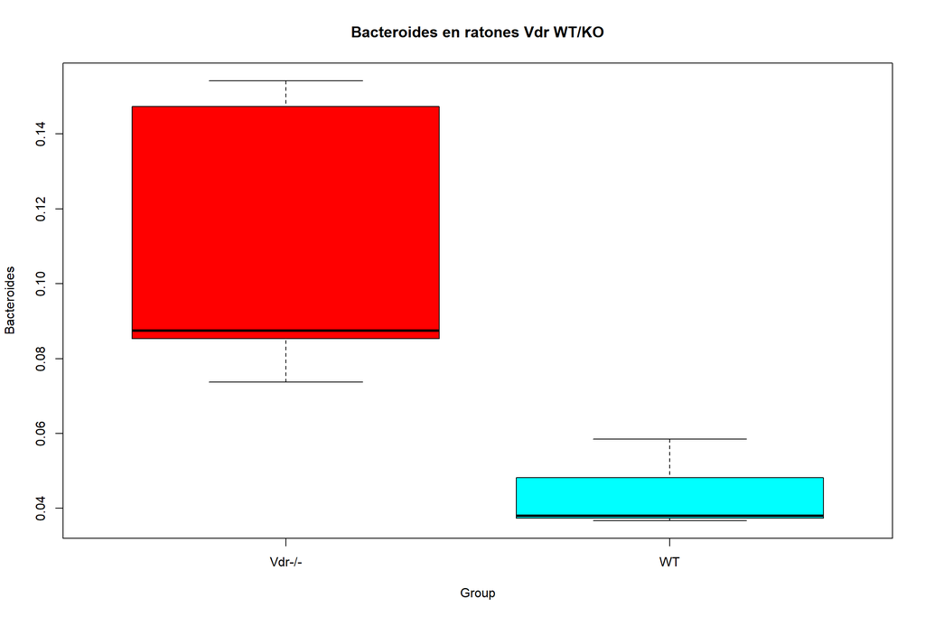

Diagrama de caja de Bacteroides con Vdr-/- y grupos WT en muestras fecales.

```r
#creamos un boxplot con los  grupos
#Diagrama de caja de Bacteroides con grupos Vdr-/- y WT en muestras fecales
boxplot(Bacteroides ~ Group,data=Fecal_Bacteroides_G, col=rainbow(2),
        main="Bacteroides en ratones Vdr WT/KO")
```

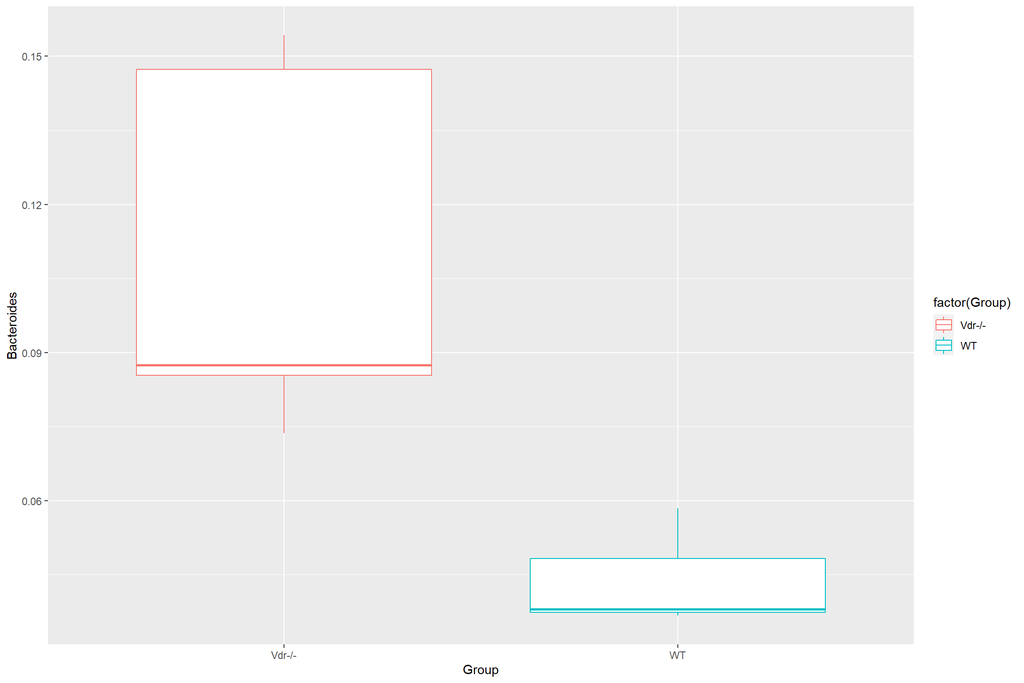

Diagrama de caja de Bacteroides con Vdr-/- y grupos WT en muestras fecales generadas usando ggplot.

```r
#con ggplot generamos el boxplot con el siguente codigo
ggplot(Fecal_Bacteroides_G, aes(x=Group, y=Bacteroides,col=factor(Group))) +
  geom_boxplot(notch=FALSE)
```

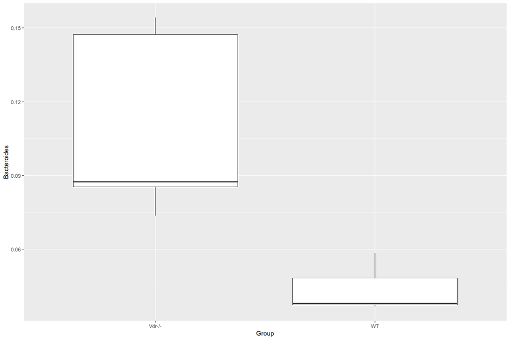

Diagrama de caja de Bacteroides con Vdr-/- y grupos WT en muestras fecales generadas usando ggplot con otro formato.

```r
#Diagrama de caja  bacterias Bacteroides con Vdr−/− y WT en muestras fecales
#generados usando ggplot
ggplot(Fecal_Bacteroides_G, aes(x=Group, y=Bacteroides)) +
  geom_boxplot(outlier.colour="red", outlier.shape=8, outlier.size=4) #+
```

```r
  #layer(stat_params = list(binwidth = 2))
#el argumento bindwith=2 genera un error
```

Los diagramas de caja muestran taxones (**Bacteriodes**) en ratones WT (WT, n = 3) y para ratones knockout de Vdr (KO, n = 5)

```r
#Hacemos una prueba de suma de rangos de Wilcoxon
fit_w_b <- wilcox.test(Bacteroides ~ Group,data=Fecal_Bacteroides_G)
fit_w_b
```

```
##
##  Wilcoxon rank sum exact test
##
## data:  Bacteroides by Group
## W = 15, p-value = 0.03571
## alternative hypothesis: true location shift is not equal to 0
```

La prueba de Wilcoxon anterior indica que existe una abundancia relativa estadísticamente significativa de Bacteroides entre los ratones Vdr$-/-$ y WT. Podemos concluir que Vdr knockout enriquece Bacteroides.

## Comparación de taxones presentes o ausentes utilizando la Prueba de chi-cuadrado

Una prueba de chi-cuadrado, también conocida como prueba $\chi^2$, a menudo utilizada como abreviatura de la prueba de chi-cuadrado de Pearson, fué propuesta e investigada por primera vez por Karl Pearson en 1900 (Pearson 1900). La prueba $\chi^2$ se aplica a conjuntos de datos categóricos para probar si la distribución de frecuencia observada difiere de una distribución teórica o propuesta (pruebas de bondad de ajuste) e investigar si la variable fila y la variable columna en una tabla de contingencia son independientes entre sí (pruebas de independencia). El estadístico de prueba de bondad de ajuste viene dado por:

$$\chi^2= \sum_{i = 1}^{n}\frac{(O_i-E_i)^2}{E_i}=N\sum_{i =
1}^{n}\frac{(O_i/N-p_i)^2}{p_i},$$
Donde:

| $X^2$ | El estadístico de prueba de Pearson, que se acerca asintóticamente a la distribución $\chi^2$ |
| --- | --- |
| $O_i$ | número de observaciones de categoría $i$ |
| $N$ | Número total de observaciones |
| $E_i=Np_i$ | Frecuencia esperada(teórica) de la categoría $i$ bajo la hipótesis nula |
| $p_i$ | probabilidad de categoría $i$ en la población |
| $n$ | número de celdas en la tabla |

El estadístico de prueba de independencia se da de la siguiente forma.

$$\chi^2= \sum_{i = 1}^{r}\sum_{j =
1}^{c}\frac{(O_{i,j}-E_{i,j})^2}{E_{i,j}}=N\sum_{i,j}p_{i.}p_{.j}\left(\frac{(O_{i,j}/N)-p_{i.}p_{.j}}{p_{i.}p_{.j}}\right)^2,$$

Donde

| $N$ | Tamaño total de la muestra (la suma de todas las celdas de la tabla) |
| --- | --- |
| $E_{ij}=Np_{i.}p_{.j}$ | Frecuencia esperada(teórica) bajo la hipótesis nula de independencia |
| $p_{i.}=\frac{O_{i.}}{N}=\sum_{j=1}^{c}\frac{O_{ij}}{N}$ | Probabilidad de observaciones de categoría $i$ ignorando el atributo |
|  | de columna (probabilidad de totales de fila) |
| $p_{.j}=\frac{O_{.j}}{N}=\sum_{i=1}^{r}\frac{O_{ij}}{N}$ | Probabilidad de observaciones de categoría $j$ ignorando el atributo de |
|  | fila (probabilidad de totales de columna) |

Como regla general, se requiere que todos los recuentos de celdas esperados sean iguales o superiores a $5$ para proporcionar una aproximación adecuada a la distribución de la distribución de Chi-cuadrado (Wackerly et al. 2002), aunque Cochran (1952) señaló que este valor podría ser tan bajo como $1$ para algunas situaciones.

En esta sección, ilustramos la prueba $\chi^2$ para comparar bacterias Parabacteroides en el conjunto de datos de ratones Vdr utilizando muestras cecales. Para ilustrar la prueba $\chi^2$, transformamos los datos de conteo de abundancia de Parabacteroides en una variable binaria. Los datos de conteo en la tabla de abundancia para el taxón Parabacteroides se transformarían a $0$ si el taxón está ausente en la muestra o $1$ si el taxón está presente en la muestra. Los datos transformados se resumen en la tabla 1.

| **Grupo** | **Presencia** | **Ausencia** | **Total** |
| --- | --- | --- | --- |
| **Vdr-/-** | 3 (60%) | 2 (40%) | 5 |
| **WT** | 3 (100%) | 0 (0%) | 3 |

Tabla1: Distribución de la tasa de Parabacteroides en muestras Vdr $-/-$ y WT obtenidas del conjunto de datos de ratones Vdr.

Primero, observe los datos de abundancia para identificar Parabacteroides y subdividirlas.

```r
#Distribution of the Parabacteroides rate
#across Vdr−/− and WT cecal samples obtained
abund_table[1:16,1:27]
```

```
##                Tannerella Lactococcus Lactobacillus Lactobacillus::Lactococcus
## 5_15_drySt-28F        476         326            94                          1
## 20_12_CeSt-28F         67         737           597                         12
## 1_11_drySt-28F        549        2297           434                         25
## 2_12_drySt-28F        578         548           719                          5
## 3_13_drySt-28F        996        2378           322                         17
## 4_14_drySt-28F        404         471           205                          1
## 7_22_drySt-28F        319         882           644                         13
## 8_23_drySt-28F        526        1973          2340                         15
## 9_24_drySt-28F        424        2308          1000                         14
## 19_11_CeSt-28F          0         422           330                          7
## 21_13_CeSt-28F          6         173           639                          0
## 22_14_CeSt-28F         20         580           633                          3
## 23_15_CeSt-28F         37        4867          1819                         25
## 25_22_CeSt-28F         38         707           625                          9
## 26_23_CeSt-28F         81        1404          1361                         10
## 27_24_CeSt-28F        235        1913           365                         13
##                Parasutterella Helicobacter Prevotella Bacteroides Barnesiella
## 5_15_drySt-28F              1           89        121         273           9
## 20_12_CeSt-28F              0            0          7          34           1
## 1_11_drySt-28F              1            0        289         958           2
## 2_12_drySt-28F              4           13         99         377           2
## 3_13_drySt-28F              2           24        335         526           1
## 4_14_drySt-28F              0           32        143         200           2
## 7_22_drySt-28F              0            3        111          86           0
## 8_23_drySt-28F             12            0         89         424           3
## 9_24_drySt-28F              1            0         84         202           1
## 19_11_CeSt-28F              0            0          0           0           0
## 21_13_CeSt-28F              0            0          1           5           0
## 22_14_CeSt-28F              0            0          3          20           0
## 23_15_CeSt-28F              2            0         10          31           1
## 25_22_CeSt-28F              0            0          7          19           0
## 26_23_CeSt-28F              2            0          5          46           0
## 27_24_CeSt-28F              0            0         25         122           1
##                Odoribacter Eubacterium Allobaculum Roseburia Clostridium
## 5_15_drySt-28F           1          52           0         1         130
## 20_12_CeSt-28F           0         131         241        18         401
## 1_11_drySt-28F          22         144           0        12         597
## 2_12_drySt-28F           7         238         271        44         815
## 3_13_drySt-28F           2         129          21         1         203
```

[output cut: 81 more lines]

```
## 20_12_CeSt-28F                              0          13               0
## 1_11_drySt-28F                              0         116              25
## 2_12_drySt-28F                              6         119               4
## 3_13_drySt-28F                              0          10              14
## 4_14_drySt-28F                              0          12              16
## 7_22_drySt-28F                              0           0               5
## 8_23_drySt-28F                              1          22              14
## 9_24_drySt-28F                              1          12               6
## 19_11_CeSt-28F                              1           2               0
## 21_13_CeSt-28F                              1           1               1
## 22_14_CeSt-28F                              0           1               4
## 23_15_CeSt-28F                              5          36              15
## 25_22_CeSt-28F                              0           0               5
## 26_23_CeSt-28F                              4          43               4
## 27_24_CeSt-28F                              1          37               6
```

```r
(Parabacteroides <- abund_table[,27])
```

```
## 5_15_drySt-28F 20_12_CeSt-28F 1_11_drySt-28F 2_12_drySt-28F 3_13_drySt-28F
##             45              0             25              4             14
## 4_14_drySt-28F 7_22_drySt-28F 8_23_drySt-28F 9_24_drySt-28F 19_11_CeSt-28F
##             16              5             14              6              0
## 21_13_CeSt-28F 22_14_CeSt-28F 23_15_CeSt-28F 25_22_CeSt-28F 26_23_CeSt-28F
##              1              4             15              5              4
## 27_24_CeSt-28F
##              6
```

Luego, combinamos los datos subdivididos con el marco de datos de agrupación.

```r
#combina los datos subdivididos
Parabacteroides_G <-cbind(Parabacteroides, grouping)
rownames(Parabacteroides_G)<-NULL
```

Dado que el dataframe combinado incluye muestras fecales y cecales, subdividamos datos cecales de este dataframe

```r
Cecal_Parabacteroides_G <- subset(Parabacteroides_G, Location=="Cecal")
Cecal_Parabacteroides_G
```

```
##    Parabacteroides Location  Group
## 2                0    Cecal Vdr-/-
## 10               0    Cecal Vdr-/-
## 11               1    Cecal Vdr-/-
## 12               4    Cecal Vdr-/-
## 13              15    Cecal Vdr-/-
## 14               5    Cecal     WT
## 15               4    Cecal     WT
## 16               6    Cecal     WT
```

Antes, recodificamos una variable binaria: “Presente”, para la prueba de Chi-cuadrado.

```r
Cecal_Parabacteroides_G$Present <- ifelse((
  Cecal_Parabacteroides_G$Parabacteroides > 0), "Present","Absent")
Cecal_Parabacteroides_G
```

```
##    Parabacteroides Location  Group Present
## 2                0    Cecal Vdr-/-  Absent
## 10               0    Cecal Vdr-/-  Absent
## 11               1    Cecal Vdr-/- Present
## 12               4    Cecal Vdr-/- Present
## 13              15    Cecal Vdr-/- Present
## 14               5    Cecal     WT Present
## 15               4    Cecal     WT Present
## 16               6    Cecal     WT Present
```

El siguiente código es usado para crear una prueba de Chi-cuadrado

```r
library(MASS)
tbl = table(Cecal_Parabacteroides_G$Group, Cecal_Parabacteroides_G$Present)
tbl
```

```
##
##          Absent Present
##   Vdr-/-      2       3
##   WT          0       3
```

```r
chi <- chisq.test(tbl)
```

```
## Warning in chisq.test(tbl): Chi-squared approximation may be incorrect
```

```r
chi
```

```
##
##  Pearson's Chi-squared test with Yates' continuity correction
##
## data:  tbl
## X-squared = 0.17778, df = 1, p-value = 0.6733
```

```r
#prueba de exactitud de fisher
fisher <- fisher.test(tbl)
fisher
```

```
##
##  Fisher's Exact Test for Count Data
##
## data:  tbl
## p-value = 0.4643
## alternative hypothesis: true odds ratio is not equal to 1
## 95 percent confidence interval:
##  0.1090089       Inf
## sample estimates:
## odds ratio
##        Inf
```

El resultado de la prueba de exactitud de Fisher tampoco es significativo con un $p-$valor de 0.4642857, *lo que es consistente con la prueba de Chi-cuadrado*. Sin embargo, es difícil tener conclusiones sobre la prueba con el intervalo de confianza infinito.

# Comparación entre más de dos grupos usando ANOVA

## ANOVA de una vía

El análisis de varianza (ANOVA) fue propuesto por Ronal Fisher en 1918 y se hizo bien conocido después de la publicación del libro de Fisher, *“Statitiscal Methods for Research Workers”* en 1925. El ANOVA generaliza la prueba $t$ de dos muestras a más de dos grupos. La **hipótesis nula** del ANOVA es: *Todas las medias de grupos comparados son iguales*. El análisis usando ANOVA se basa en un supuesto de *normalidad* de los datos subyacentes. Sin embargo, la composición de la mayoría de los datos de comunidades microbiana, especialmente datos multivariados, no están normalmente distribuidos, por lo tanto, ANOVA solo es usado para comparar análisis univariado de mediciones de alfa diversidad. Para datos de composición comunitaria multivariante, se aplica una versión no paramétrica La formación de la estadística de prueba se realiza mediante la partición tradicional de la suma de cuadrados (división de la variación). La ecuación de definición de la muestra varianza es;

$$s^{2} = \frac{1}{n - 1}
{\sum^{n}_{i=1}(y_{i} - \bar y)^{2}}$$

donde $s^{2} = $ varianza de la muestra. La varianza de la muestra es calculada por la suma de cuadrados (SS) dividido por $n-1$ (grados de libertad, DF). El resultado es llamado media cuadrada (MS) y los términos cuadrados son desviaciones de la media simple. La técnica fundamental del ANOVA divide la suma total de cuadrados (SS) de desviaciones en dos componentes: suma de cuadrados relacionados con el tratamiento y suma de cuadrados relacionados con el error:

$$SS_{Total} = SS_{Tratamientos} + SS_{Error}$$

El número de grados de libertad, DF, pueden ser particionados de una manera similar:

$$DF_{Total} = DF_{Tratamientos} + DF_{Error}$$

La prueba $F$ es usada para comparar los factores de la desviación total. El valor $F$ es obtenido por la división de la varianza entre tratamientos por la varianza dentro de tratamientos. La prueba estadística $F$ en un ANOVA de una vía esta dado por:

$$F = \frac{MS_{Tratamientos}}{MS_{Error}} =
\frac{SS_{Tratamientos}/(K-1)}{SS_{Error}/(N-1)}$$

donde $MS =$ media cuadrada, $K =$ número de tratamientos y $N =$ número total de muestras. Para ilustrar el ANOVA en el estudio de la composición de la comunidad del microbioma, utilizamos los datos de nuestro ratón $Vdr^{-/-}$. Una hipótesis de este estudio es que el estado de $Vdr$ y la localización intestinal no tienen efectos en la comunidad bacteriana del intestino. Analizamos las medidas de diversidad alfa de Chao 1 utilizando ANOVA para abordar esta hipótesis. Los siguientes códigos crean un marco de datos de riqueza Chao1 y añaden la información de los grupos a este marco de datos

```r
CH <- estimateR(abund_table)[2,]
df_CH <- data.frame(sample = names(CH), value = CH,
                    measure = rep("Chao1", length(CH)))
df_CH_G <- cbind(df_CH, grouping)
rownames(df_G) <- NULL
df_CH_G
```

```
##                        sample     value measure Location  Group
## 5_15_drySt-28F 5_15_drySt-28F  94.75000   Chao1    Fecal Vdr-/-
## 20_12_CeSt-28F 20_12_CeSt-28F  59.80000   Chao1    Cecal Vdr-/-
## 1_11_drySt-28F 1_11_drySt-28F  77.00000   Chao1    Fecal Vdr-/-
## 2_12_drySt-28F 2_12_drySt-28F 103.27273   Chao1    Fecal Vdr-/-
## 3_13_drySt-28F 3_13_drySt-28F  85.66667   Chao1    Fecal Vdr-/-
## 4_14_drySt-28F 4_14_drySt-28F  55.14286   Chao1    Fecal Vdr-/-
## 7_22_drySt-28F 7_22_drySt-28F  62.75000   Chao1    Fecal     WT
## 8_23_drySt-28F 8_23_drySt-28F  67.66667   Chao1    Fecal     WT
## 9_24_drySt-28F 9_24_drySt-28F  80.50000   Chao1    Fecal     WT
## 19_11_CeSt-28F 19_11_CeSt-28F  52.16667   Chao1    Cecal Vdr-/-
## 21_13_CeSt-28F 21_13_CeSt-28F  55.00000   Chao1    Cecal Vdr-/-
## 22_14_CeSt-28F 22_14_CeSt-28F  59.00000   Chao1    Cecal Vdr-/-
## 23_15_CeSt-28F 23_15_CeSt-28F  60.87500   Chao1    Cecal Vdr-/-
## 25_22_CeSt-28F 25_22_CeSt-28F  51.00000   Chao1    Cecal     WT
## 26_23_CeSt-28F 26_23_CeSt-28F 112.85714   Chao1    Cecal     WT
## 27_24_CeSt-28F 27_24_CeSt-28F  78.05882   Chao1    Cecal     WT
```

Los nuevos 4 niveles de grupo son generados usando interacción de Locación y Grupo.

```r
df_CH_G$Group4 <- with(df_CH_G, interaction(Location,Group))
df_CH_G
```

```
##                        sample     value measure Location  Group       Group4
## 5_15_drySt-28F 5_15_drySt-28F  94.75000   Chao1    Fecal Vdr-/- Fecal.Vdr-/-
## 20_12_CeSt-28F 20_12_CeSt-28F  59.80000   Chao1    Cecal Vdr-/- Cecal.Vdr-/-
## 1_11_drySt-28F 1_11_drySt-28F  77.00000   Chao1    Fecal Vdr-/- Fecal.Vdr-/-
## 2_12_drySt-28F 2_12_drySt-28F 103.27273   Chao1    Fecal Vdr-/- Fecal.Vdr-/-
## 3_13_drySt-28F 3_13_drySt-28F  85.66667   Chao1    Fecal Vdr-/- Fecal.Vdr-/-
## 4_14_drySt-28F 4_14_drySt-28F  55.14286   Chao1    Fecal Vdr-/- Fecal.Vdr-/-
## 7_22_drySt-28F 7_22_drySt-28F  62.75000   Chao1    Fecal     WT     Fecal.WT
## 8_23_drySt-28F 8_23_drySt-28F  67.66667   Chao1    Fecal     WT     Fecal.WT
## 9_24_drySt-28F 9_24_drySt-28F  80.50000   Chao1    Fecal     WT     Fecal.WT
## 19_11_CeSt-28F 19_11_CeSt-28F  52.16667   Chao1    Cecal Vdr-/- Cecal.Vdr-/-
## 21_13_CeSt-28F 21_13_CeSt-28F  55.00000   Chao1    Cecal Vdr-/- Cecal.Vdr-/-
## 22_14_CeSt-28F 22_14_CeSt-28F  59.00000   Chao1    Cecal Vdr-/- Cecal.Vdr-/-
## 23_15_CeSt-28F 23_15_CeSt-28F  60.87500   Chao1    Cecal Vdr-/- Cecal.Vdr-/-
## 25_22_CeSt-28F 25_22_CeSt-28F  51.00000   Chao1    Cecal     WT     Cecal.WT
## 26_23_CeSt-28F 26_23_CeSt-28F 112.85714   Chao1    Cecal     WT     Cecal.WT
## 27_24_CeSt-28F 27_24_CeSt-28F  78.05882   Chao1    Cecal     WT     Cecal.WT
```

Exploramos el índice de Chao usando `boxplot().`

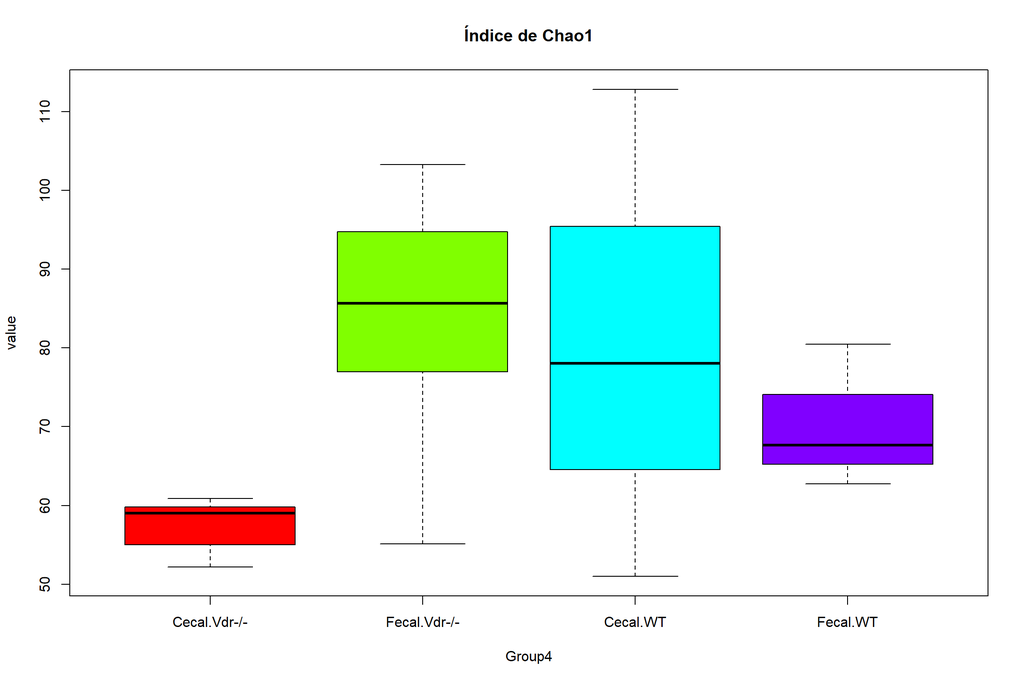

Boxplot del índice Chao 1 con cuatro grupos generados usando la función `boxplot()`.

```r
boxplot(value~Group4, data=df_CH_G, col = rainbow(4), main="Índice de Chao1")
```

El siguiente `ggplot()` genera una alta calidad de boxplot para publicarlo

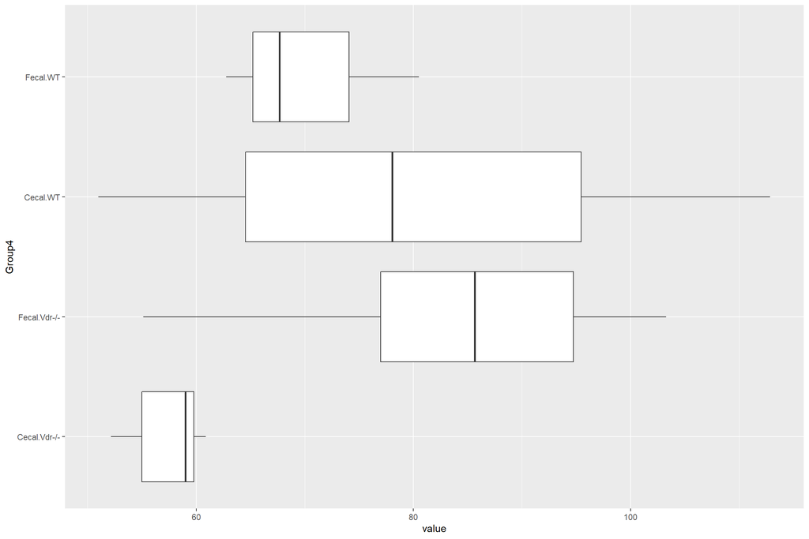

Boxplot del índice Chao 1 con cuatro grupos generados usando la función `ggplot()`.

```r
library(ggplot2)
p <- ggplot(df_CH_G, aes(x=Group4, y=value),
            col=rainbow(4), main="Índice de Chao1") +
  geom_boxplot()
p + coord_flip()
```

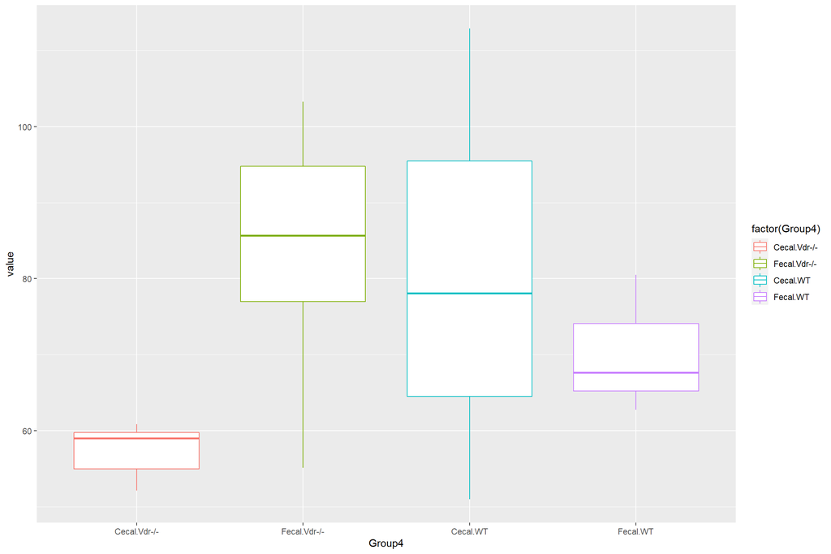

Boxplot del índice Chao 1 con cuatro grupos generados usando la función `ggplot()`.

```r
ggplot(df_CH_G, aes(x = Group4, y = value, col = factor(Group4))) +
  geom_boxplot(notch = FALSE)
```

Además de la inspección visual de la normalidad de los datos subyacentes, la homogeneidad de varianza puede ser probada. Sokal y Rohlf (2011) describen tres pruebas de este tipo: la prueba de homogeneidad de Bartlett, la prueba $F_{max}$ de Hartley y la prueba log-anova o Scheffé-Box. Para proceder a la comprobación del uso de ANOVA, primero debemos comprobar la homogeneidad de las varianzas. El software R proporciona dos pruebas: la prueba de Bartlett y la prueba de Fligner-Killeen. Para ilustrar la prueba de homogeneidad de varianzas, utilizamos las medidas de riqueza Chao 1 de los datos de los ratones $Vdr^{-/-}$ y WT de las localizaciones fecales y cecales. La hipótesis nula ($H_0$) de es que todas las varianzas de los cuatro grupos son iguales. Comenzamos con la prueba de Bartlett. Para facilitar el procesamiento de la prueba de Bartlett de Bartlett, utilizamos la función `select()` del paquete dplyr para seleccionar el grupo pertinente y las columnas de valor de Chao 1.

```r
library(dplyr)
df_CH_G4 <- dplyr::select(df_CH_G, Group4, value)
df_CH_G4
```

```
##                      Group4     value
## 5_15_drySt-28F Fecal.Vdr-/-  94.75000
## 20_12_CeSt-28F Cecal.Vdr-/-  59.80000
## 1_11_drySt-28F Fecal.Vdr-/-  77.00000
## 2_12_drySt-28F Fecal.Vdr-/- 103.27273
## 3_13_drySt-28F Fecal.Vdr-/-  85.66667
## 4_14_drySt-28F Fecal.Vdr-/-  55.14286
## 7_22_drySt-28F     Fecal.WT  62.75000
## 8_23_drySt-28F     Fecal.WT  67.66667
## 9_24_drySt-28F     Fecal.WT  80.50000
## 19_11_CeSt-28F Cecal.Vdr-/-  52.16667
## 21_13_CeSt-28F Cecal.Vdr-/-  55.00000
## 22_14_CeSt-28F Cecal.Vdr-/-  59.00000
## 23_15_CeSt-28F Cecal.Vdr-/-  60.87500
## 25_22_CeSt-28F     Cecal.WT  51.00000
## 26_23_CeSt-28F     Cecal.WT 112.85714
## 27_24_CeSt-28F     Cecal.WT  78.05882
```

Los códigos R siguientes conducen a la prueba Barlett de homogeneidad de varanzas:

```r
# No corre así
# bartlett.test(df_CH_G4, Group4)
# Se modificó pero aquí marca 3 grados de libertad y en el libro 1.
bartlett.test(df_CH_G4$value ~ df_CH_G4$Group4)
```

```
##
##  Bartlett test of homogeneity of variances
##
## data:  df_CH_G4$value by df_CH_G4$Group4
## Bartlett's K-squared = 10.227, df = 3, p-value = 0.01673
```

La función nos da el valor K al cuadrado de las pruebas estadísticas y el $p-$valor. Muestra que la hipótesis nula puede rechazarse al nivel del 5%. Como alternativa, podemos comparar el K-cuadrado de Bartlett con el valor de las tablas de chi-cuadrado, utilizando el mismo nivel de alfa y grados de libertad en la función `qchisq()`. Si Chi-cuadrado > K-cuadrado de Bartlett, aceptamos la hipótesis nula $H_0$ (homogeneidad de varianzas), de lo contrario rechazamos la hipótesis nula.

```r
# En el libro usan qchisq(0.95, 1)
# Pero en este ejemplo nos salieron 3 grados de libertad, por eso se modifico.
qchisq(0.95, 3)
```

```
## [1] 7.814728
```

Como la Chi-cuadrado es menor que la K-cuadrado de Bartlett, rechazamos la hipótesis nula $H_0$ y concluimos que las varianzas no son iguales. Ahora utilizamos la prueba de Fligner-Killeen para comprobar la homocedasticidad. La sintaxis como a continuación es bastante similar.

```r
# En el libro usa este pero sale un grado de libertad y nosotros tenemos 4 muestras
#fligner.test(df_CH_G4, Group4)
fligner.test(df_CH_G4$value ~ df_CH_G4$Group4)
```

```
##
##  Fligner-Killeen test of homogeneity of variances
##
## data:  df_CH_G4$value by df_CH_G4$Group4
## Fligner-Killeen:med chi-squared = 3.9775, df = 3, p-value = 0.2639
```

```r
fit = lm(formula = value~Group4, data = df_CH_G)
```

Entonces analizamos el modelo de ANOVA

```r
anova1 <- anova(fit)
anova1
```

```
## Analysis of Variance Table
##
## Response: value
##           Df Sum Sq Mean Sq F value Pr(>F)
## Group4     3 1925.6  641.87  2.1927 0.1418
## Residuals 12 3512.7  292.72
```

O solo usamos el siguiente código: la función `aov()` anidado dentro de la función `summary()`.

```r
summary(aov(value~Group4, data=df_CH_G))
```

```
##             Df Sum Sq Mean Sq F value Pr(>F)
## Group4       3   1926   641.9   2.193  0.142
## Residuals   12   3513   292.7
```

Podemos imprimir el [intercepto](https://rpubs.com/hllinas/R_Reg_Lineal_Simpl_Test_Parametro) usando lo siguiente.

```r
aov_fit <- aov(value~Group4, data = df_CH_G)
summary(aov_fit, intercept=T)
```

```
##             Df Sum Sq Mean Sq F value   Pr(>F)
## (Intercept)  1  83450   83450 285.080 9.97e-10 ***
## Group4       3   1926     642   2.193    0.142
## Residuals   12   3513     293
## ---
## Signif. codes:  0 '***' 0.001 '**' 0.01 '*' 0.05 '.' 0.1 ' ' 1
```

Como el valor $p$ > 0.05, aceptamos la hipótesis $H_0$: las cuatro medias no son diferentes. Podemos comprar el valor $F$ con el valor tabulado de $F$:

```r
qf(0.95, 12, 3)
```

```
## [1] 8.744641
```

Debido a que el valor tabulado de $F$ es más grande que el computado valor $F$, aceptamos la $H_0$. Los resultados del ANOVA son un poco desordenados. Puede utilizar el paquete broom para obtener las tablas ordenadas y más informativas.

```r
#install.packages("mnormt")
library("broom")
tidy(aov_fit)
```

```
## # A tibble: 2 × 6
##   term         df sumsq meansq statistic p.value
##   <chr>     <dbl> <dbl>  <dbl>     <dbl>   <dbl>
## 1 Group4        3 1926.   642.      2.19   0.142
## 2 Residuals    12 3513.   293.     NA     NA
```

```r
augment(aov_fit)
```

```
## # A tibble: 16 × 9
##    .rownames      value Group4       .fitted .resid  .hat .sigma .cooksd .std.…¹
##    <chr>          <dbl> <fct>          <dbl>  <dbl> <dbl>  <dbl>   <dbl>   <dbl>
##  1 5_15_drySt-28F  94.8 Fecal.Vdr-/-    83.2  11.6  0.2     17.4 3.58e-2   0.757
##  2 20_12_CeSt-28F  59.8 Cecal.Vdr-/-    57.4   2.43 0.2     17.9 1.58e-3   0.159
##  3 1_11_drySt-28F  77   Fecal.Vdr-/-    83.2  -6.17 0.2     17.7 1.01e-2  -0.403
##  4 2_12_drySt-28F 103.  Fecal.Vdr-/-    83.2  20.1  0.2     16.5 1.08e-1   1.31
##  5 3_13_drySt-28F  85.7 Fecal.Vdr-/-    83.2   2.50 0.2     17.9 1.67e-3   0.163
##  6 4_14_drySt-28F  55.1 Fecal.Vdr-/-    83.2 -28.0  0.2     15.2 2.10e-1  -1.83
##  7 7_22_drySt-28F  62.8 Fecal.WT        70.3  -7.56 0.333   17.7 3.66e-2  -0.541
##  8 8_23_drySt-28F  67.7 Fecal.WT        70.3  -2.64 0.333   17.8 4.46e-3  -0.189
##  9 9_24_drySt-28F  80.5 Fecal.WT        70.3  10.2  0.333   17.5 6.66e-2   0.730
## 10 19_11_CeSt-28F  52.2 Cecal.Vdr-/-    57.4  -5.20 0.2     17.8 7.22e-3  -0.340
## 11 21_13_CeSt-28F  55   Cecal.Vdr-/-    57.4  -2.37 0.2     17.9 1.50e-3  -0.155
## 12 22_14_CeSt-28F  59   Cecal.Vdr-/-    57.4   1.63 0.2     17.9 7.11e-4   0.107
## 13 23_15_CeSt-28F  60.9 Cecal.Vdr-/-    57.4   3.51 0.2     17.8 3.28e-3   0.229
## 14 25_22_CeSt-28F  51   Cecal.WT        80.6 -29.6  0.333   14.1 5.63e-1  -2.12
## 15 26_23_CeSt-28F 113.  Cecal.WT        80.6  32.2  0.333   13.3 6.65e-1   2.31
## 16 27_24_CeSt-28F  78.1 Cecal.WT        80.6  -2.58 0.333   17.8 4.26e-3  -0.185
## # … with abbreviated variable name ¹.std.resid
```

```r
glance(aov_fit)
```

```
## # A tibble: 1 × 6
##   logLik   AIC   BIC deviance  nobs r.squared
##    <dbl> <dbl> <dbl>    <dbl> <int>     <dbl>
## 1  -65.8  142.  146.    3513.    16     0.354
```

## Comparaciones a pares y comparaciones multiples de Tukey

Los resultados del ANOVA dan la prueba global de diferencia de grupos (en este caso, 4 grupos con combinación fecal, cecal, $Vdr^{-/-}$ y WT). Nuestro propósito es probar también cada diferencia de pares asociada a la riqueza de Chao 1. Los siguientes pasos sirven para ilustrar las capacidades de la prueba $t$ por pares y las comparaciones múltiples ad hoc de Tukey en R.

Vamos a ejecutar la prueba $t$ por pares no ajustada para los cuatro grupos. La configuración por defecto en R para esta prueba es ajustar los $p-$valores como post hoc usando el método Holm, así que para obtener $p$valores no ajustados, debe especificar `p.adjust = "none"`. El valor por defecto de R asume la homogeneidad de la varianza, por lo que no es necesario especificar `pool. sd = T`. Si sus datos tienen una varianza desigual, debe utilizar `pool.sd = F`.

```r
# Pruebas de diferencias de medias por pares
pairwise.t.test(df_CH_G$value, df_CH_G$Group4,
                p.adjust = "none", pool.sd = T)
```

```
##
##  Pairwise comparisons using t tests with pooled SD
##
## data:  df_CH_G$value and df_CH_G$Group4
##
##              Cecal.Vdr-/- Fecal.Vdr-/- Cecal.WT
## Fecal.Vdr-/- 0.035        -            -
## Cecal.WT     0.087        0.843        -
## Fecal.WT     0.321        0.324        0.474
##
## P value adjustment method: none
```

Si no hacemos ningún ajuste a nuestros valores $p$, hay diferencias estadísticamente entre $Vdr^{-/-}$ fecal, $Vdr^{-/-}$ cecal, y marginalmente diferencias estadísticas entre WT cecal y $Vdr^{-/-}$ cecal. Estas diferencias se visualizan en el `boxplot`. Como observamos, la función `p.adjust()` está anidada dentro de la función `pairwise.t.test()` de pares. Esta es una función básica y muy útil de R. Puede utilizarse para controlar el error de tipo I de la familia. La función `p.adjust()` puede anidarse en otra función, o ser llamada de forma independiente. En una llamada independiente, la sintaxis se da a continuación:
$$p.adjust(p, method = p.adjust.methods, n = length(p))$$

donde, $p =$ vector numérico de valores $p$, $método =$ método de corrección, $n =$ número de comparaciones, debe ser al menos $length(p)$. Los métodos de ajuste incluyen `c("bonferroni", "holm", "hochberg", "hommel", "BH", "BY", "fdr", "none")`. Donde “bonferroni” es la corrección de Bonferroni en la que los $p-$valores se multiplican por el número de comparaciones; “holm”, “hochberg”, “hommel”, “BH”, “BY”, “fdr” se refieren a Holm (1979), Hochberg (1988), Hommel (1988), Benjamini y Hochberg (1995) y Benjamini y Yekutieli (2001), y “fdr” es un alias de “BH”. Son correcciones menos conservadoras.

```r
# Ajuste conservador de Bonferroni
pairwise.t.test(df_CH_G$value, df_CH_G$Group4,
                p.adjust = "bonferroni", pool.sd = T)
```

```
##
##  Pairwise comparisons using t tests with pooled SD
##
## data:  df_CH_G$value and df_CH_G$Group4
##
##              Cecal.Vdr-/- Fecal.Vdr-/- Cecal.WT
## Fecal.Vdr-/- 0.21         -            -
## Cecal.WT     0.52         1.00         -
## Fecal.WT     1.00         1.00         1.00
##
## P value adjustment method: bonferroni
```

```r
# Método de Holm
pairwise.t.test(df_CH_G$value, df_CH_G$Group4,
                p.adjust = "holm", pool.sd = T)
```

```
##
##  Pairwise comparisons using t tests with pooled SD
##
## data:  df_CH_G$value and df_CH_G$Group4
##
##              Cecal.Vdr-/- Fecal.Vdr-/- Cecal.WT
## Fecal.Vdr-/- 0.21         -            -
## Cecal.WT     0.44         1.00         -
## Fecal.WT     1.00         1.00         1.00
##
## P value adjustment method: holm
```

```r
# Método de Benjamini & Hochberg(BH)
pairwise.t.test(df_CH_G$value, df_CH_G$Group4,
                p.adjust= "BH", pool.sd = T)
```

```
##
##  Pairwise comparisons using t tests with pooled SD
##
## data:  df_CH_G$value and df_CH_G$Group4
##
##              Cecal.Vdr-/- Fecal.Vdr-/- Cecal.WT
## Fecal.Vdr-/- 0.21         -            -
## Cecal.WT     0.26         0.84         -
## Fecal.WT     0.49         0.49         0.57
##
## P value adjustment method: BH
```

```r
# Método de Benjamini & Yekutieli
pairwise.t.test(df_CH_G$value, df_CH_G$Group4,
                p.adjust = "BY", pool.sd = T)
```

```
##
##  Pairwise comparisons using t tests with pooled SD
##
## data:  df_CH_G$value and df_CH_G$Group4
##
##              Cecal.Vdr-/- Fecal.Vdr-/- Cecal.WT
## Fecal.Vdr-/- 0.51         -            -
## Cecal.WT     0.64         1.00         -
## Fecal.WT     1.00         1.00         1.00
##
## P value adjustment method: BY
```

Los cuatro ajustes anteriores no ofrecen diferencias significativas en las comparaciones por pares. Los ajustes conservadores de Bonferroni y Benjamini & Yekutieli tienen los mayores $p-$valores. Con el método de Benjamini y Hochberg ninguna de las comparaciones son significativas, pero sus valores p ajustados son menores. El método Benjamini & Hochberg es más potente en este caso. Tanto el método de Benjamini & Hochberg (BH) como el de Benjamini & Yekutieli (BY) son para ajustar la “tasa de falsos descubrimientos” (FDR). En realidad no es un verdadero control de error por familia. Los métodos de la Falsa Tasa de Descubrimiento encuentran los mismos resultados: todas las comparaciones por pares no presentan diferencias significativas. A continuación, vamos a mostrar el uso de la función `TukeyHSD()` para hacer comparaciones múltiples de Tukey de medias y obtener sus intervalos de confianza. La forma de llamar a esta función es similar a la función `summary()`. Toma la variable del cálculo original de ANOVA original como uno de sus argumentos.

```r
# Comparaciones multiple de medias Tukey
TukeyHSD(aov_fit, conf.level=.95)
```

```
##   Tukey multiple comparisons of means
##     95% family-wise confidence level
##
## Fit: aov(formula = value ~ Group4, data = df_CH_G)
##
## $Group4
##                                 diff        lwr      upr     p adj
## Fecal.Vdr-/--Cecal.Vdr-/-  25.798117  -6.327765 57.92400 0.1333624
## Cecal.WT-Cecal.Vdr-/-      23.270322 -13.825451 60.36609 0.2935302
## Fecal.WT-Cecal.Vdr-/-      12.937222 -24.158550 50.03299 0.7327590
## Cecal.WT-Fecal.Vdr-/-      -2.527795 -39.623567 34.56798 0.9969042
## Fecal.WT-Fecal.Vdr-/-     -12.860895 -49.956667 24.23488 0.7361596
## Fecal.WT-Cecal.WT         -10.333100 -51.807435 31.14123 0.8792446
```

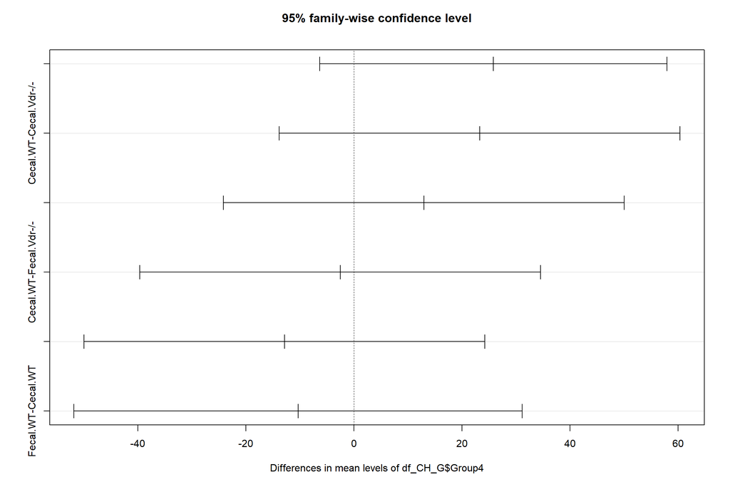

Gráfico de Tukey de comparaciones múltiples de medias y su intervalo de confianza en datos de ratón $Vdr^{-/-}$`.

```r
# Gráfico
plot(TukeyHSD(aov(df_CH_G$value~df_CH_G$Group4), conf.level=.95))
```

# Comparaciones entre más de dos grupos usando la prueba de Kruskal-Wallis

## Prueba de Kruskal-Wallis

La prueba de Kruskal-Wallis o ANOVA unidireccional sobre rangos, llamada así por William Kruskal y W.Allen Wallis, es un método no paramétrico para comprobar si las muestras proceden de la misma distribución (Kruskal y Wallis 1952; Daniel 1990). *El equivalente paramétrico de la prueba de Kruskal-Wallis es el ANOVA de una vía*. La ampliación es la prueba $U$ de Mann-Whitney a más de dos grupos. La hipótesis nula de la prueba de Kruskal-Wallis es que los *rangos medios de los grupos son los mismos*. A diferencia del ANOVA unidireccional análogo, la prueba no paramétrica de *Kruskal-Wallis no asume una distribución normal de los datos subyacentes*. Se ha utilizado ampliamente en investigación del microbioma. Por ejemplo, los datos del microbioma posteriores a la secuenciación no están distribuidos normalmente y contienen algunos valores atípicos importantes. Por lo tanto, es conveniente utilizar rangos en lugar de valores reales para evitar que las pruebas se vean afectadas por la presencia de valores atípicos o por una distribución no normal. La estadística de la prueba consta de cuatro pasos principales:

- *Paso 1*. Clasificar todos los datos de todos los grupos juntos en una única serie en orden ascendente, es decir, clasificar los datos de 1 a N ignorando la pertenencia a un grupo.
- *Paso 2*. Asignar los valores empatados promediando su posición en el ranking.
- *Paso 3*. Sumar los diferentes rangos, por ejemplo, $R_1$ $R_2$ $R_3$… para cada uno de los diferentes grupos.
- *Paso 4*. Calcula la estadística de la prueba aplicando la siguiente fórmula:

$$H = \frac{12}{n(n+1)}\sum^k_{i=1}\frac{R^{2}_{i}}{n_{i}}-3(n+1)$$

donde

- $H$ Prueba estadística de Kruskal-Wallis.
- $n$ número total de mediciones en todas las muestras.
- $n_{i}$ número de mediciones en la muestra de la población $i$.
- $k$ número de poblaciones.
- $R_{i}$ rango de sumas para la muestra $i$.

El estadístico de la prueba de Kruskal-Wallis es aproximadamente una distribución chi-cuadrado, con $k - 1$ grados de libertad si los valores de $n_{i}$ son “grandes”. La aproximación se acepta generalmente como adecuada cuando cada uno de los valores de $n_{i}$ es mayor o igual a 5.

## Comparación de diversidades entre grupos

La prueba de Kruskal-Wallis o ANOVA de una vía se realiza para comparar grupos múltiples cuyos datos no siguen una distribución normal. Esta prueba es similar a la prueba de suma de rangos de Wilcoxon para dos muestras. Primero utilizamos los datos de nuestros ratones $Vdr^{-/-}$ para ilustrar esta prueba.

```r
library("dplyr")
Data <- mutate(df_CH_G, Group = factor(df_CH_G$Group4,
                                       levels = unique(df_CH_G$Group4)))
```

Estadística descriptiva

```r
library("FSA")
Summarize(value ~ Group4, data = df_CH_G)
```

```
##         Group4 n     mean        sd      min       Q1   median       Q3
## 1 Cecal.Vdr-/- 5 57.36833  3.658497 52.16667 55.00000 59.00000 59.80000
## 2 Fecal.Vdr-/- 5 83.16645 18.493505 55.14286 77.00000 85.66667 94.75000
## 3     Cecal.WT 3 80.63866 31.009163 51.00000 64.52941 78.05882 95.45798
## 4     Fecal.WT 3 70.30556  9.164520 62.75000 65.20833 67.66667 74.08333
##        max
## 1  60.8750
## 2 103.2727
## 3 112.8571
## 4  80.5000
```

Generamos Histograma por grupo

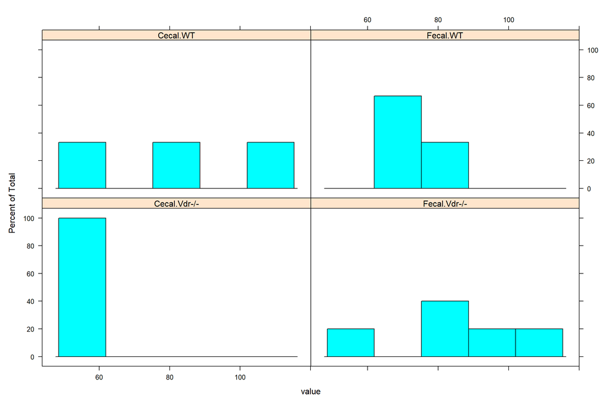

Distribuciones de los valores entre los grupos`.

```r
# Gráficos individuales en un panel de 2X2
library("lattice")
histogram(~ value|Group4, data=df_CH_G,layout=c(2,2))
```

El histograma muestra que las distribuciones de los valores entre los grupos son diferentes en este caso. Ahora realizamos la prueba de Kruskal-Wallis para comparar las diferencias de medianas utilizando la función `kruskal.test()`.

```r
# Prueba de Kruskal-Wallis de la riqueza de Chao1
kruskal_test <- kruskal.test(value ~ Group4, data = df_CH_G)
kruskal_test
```

```
##
##  Kruskal-Wallis rank sum test
##
## data:  value by Group4
## Kruskal-Wallis chi-squared = 5.2353, df = 3, p-value = 0.1554
```

El valor de la estadística de la prueba es 5.2352941 con un $p-$valor superior a 0,05 y también es inferior a la tabulación chi-cuadrado:

```r
qchisq(0.950, 3)
```

```
## [1] 7.814728
```

Por tanto, aceptamos la hipótesis nula $H_0$: las medianas de los 4 grupos son estadísticamente iguales a un nivel significativo del 5%. Generalmente, se realiza un análisis post hoc para encontrar qué niveles de los grupos son diferentes entre sí si la prueba de Kruskal-Wallis es significativa. En este caso, la prueba de Kruskal-Wallis no es significativa. A modo de ilustración, realizamos dos pruebas post hoc: La prueba de Nemenyi y la prueba de Dunn. De forma similar al ANOVA, podemos elegir un método para ajustar los valores $p$ para controlar la tasa de error familiar o para controlar la tasa de falsos descubrimientos. Al introducir `?p.adjust` en R o RStudio, aparece un enlace al documento “Adjust P-values for Multiple Comparisons”. Puede consultar los detalles de los métodos de ajuste desde este enlace.

### Prueba de Nemenyi para comparaciones múltiples

La prueba de Nemenyi se realiza mediante la función `NemenyiTest()` del paquete DescTools. Primero cargamos el paquete DescTools y llamamos a la función `NemenyiTest()`. El método para ajustar los $p-$valores debe ser uno de “tukey”, “chisq”. En este caso elegimos el método Tukey

```r
library("DescTools")
# Método de Tukey para ajustar valores p
Test_N <- NemenyiTest(x = df_CH_G$value,
                 g = df_CH_G$Group4,
                 dist="tukey")
Test_N
```

```
##
##  Nemenyi's test of multiple comparisons for independent samples (tukey)
##
##                           mean.rank.diff   pval
## Fecal.Vdr-/--Cecal.Vdr-/-      6.6000000 0.1254
## Cecal.WT-Cecal.Vdr-/-          4.7333333 0.5237
## Fecal.WT-Cecal.Vdr-/-          5.0666667 0.4636
## Cecal.WT-Fecal.Vdr-/-         -1.8666667 0.9501
## Fecal.WT-Fecal.Vdr-/-         -1.5333333 0.9713
## Fecal.WT-Cecal.WT              0.3333333 0.9998
## ---
## Signif. codes:  0 '***' 0.001 '**' 0.01 '*' 0.05 '.' 0.1 ' ' 1
```

La prueba de Nemenyi muestra que no hay diferencias significativas en el rango medio de la diversidad Chao 1 entre localizaciones y genotipos en las muestras fecales y cecales de vdr knockout utilizando el método de ajuste de Tukey. Sin embargo, cuando los grupos tienen números desiguales de observaciones, la prueba de Nemenyi es inadecuada, y la prueba de Dunn es apropiada (Zar 2010).

### Prueba de Dunn para comparaciones múltiples

La prueba post hoc de Kruskal-Wallis más popular es la prueba de Dunn. Podemos realizar la prueba de Dunn utilizando la función `dunnTest()` del paquete FSA. A continuación, llamamos a la función función `dunnTest()` y utilizamos el método de Benjamini y Hochberg para ajustar los valores $p$.

```r
library("FSA")
# "bh" sugiere el método de Benjamini y Hochberg para ajustar los valores p
Test_N <- dunnTest(df_CH_G$value ~ df_CH_G$Group4,
                   data = df_CH_G, method="bh")
Test_N
```

```
## Dunn (1964) Kruskal-Wallis multiple comparison
```

```
##   p-values adjusted with the Benjamini-Hochberg method.
```

```
##                    Comparison           Z    P.unadj     P.adj
## 1     Cecal.Vdr-/- - Cecal.WT -1.36136286 0.17339905 0.3467981
## 2 Cecal.Vdr-/- - Fecal.Vdr-/- -2.19189684 0.02838696 0.1703217
## 3     Cecal.WT - Fecal.Vdr-/- -0.53687549 0.59135362 0.8870304
## 4     Cecal.Vdr-/- - Fecal.WT -1.45723348 0.14505194 0.4351558
## 5         Cecal.WT - Fecal.WT -0.08574929 0.93166572 0.9316657
## 6     Fecal.Vdr-/- - Fecal.WT  0.44100487 0.65920947 0.7910514
```

La prueba de Dunn muestra que hay una diferencia estadísticamente significativa de la diversidad Chao 1 entre las muestras cecales y fecales de $Vdr^{-/-}$. Sin embargo, después de ajustar los valores comparación múltiple con el método Benjamini-Hochberg, no hay términos estadísticamente significativos entre las localizaciones y los genotipos de las muestras.

## Encontrar taxones significativos entre los grupos

En esta sección, utilizamos la prueba de Kruskal-Wallis para ilustrar cómo encontrar taxones significativos entre los grupos. Supongamos que queremos saber si existen taxones significativos entre muestras de ratones $Vdr^{-/-}$ y WT de ubicaciones fecales y cecales. Usamos el test de prueba de Kruskal-Wallis para cada uno de los 248 taxones (bacterias) en el conjunto de datos. Primero, normalizamos los datos de abundancia y los convertimos en un marco de datos. Un método de normalización es utilizar la transformación logarítmica.

```r
data <- log((abund_table+1)/(rowSums(abund_table)+dim(abund_table)[2]))
df <- as.data.frame(data)
```

Otro método de normalización es convertir las cuentas de abundancia en abundancia relativa

```r
df <- as.data.frame(abund_table/rowSums(abund_table))
```

A continuación, utilizamos la función `kruskal.test()` y una función iterativa de R para realizar 248 pruebas (cada una para una bacteria). La función `kruskal.test()` tiene varios componentes componentes clave:

- La prueba es un bucle para todos los taxones (columnas) con los códigos “`for (i in 1:dim(df)[2])`”.
- Para cada bucle, ejecuta la prueba de Kruskal-Wallis con los códigos “`KW_test <- kruskal.test(df[,i], g=Grupo4)`”.
- Los resultados se almacenan en un marco de datos con una fila por muestra y una columna por cada $p-$valor de la prueba KW.
- Informe el número de pruebas con la función cat “`cat(paste("Kruskal-Wallis test for ", names(df)[i], " ", i, "/", dim(df)[2], "; p-value=", KW_test$p.value,"\n")", sep="")`”.

```r
KW_table <- data.frame()
for (i in 1:dim(df)[2]) {
  # Coremos prueba KW para cada bacteria
  KW_test <- kruskal.test(df[,i], g=df_CH_G$Group4)
  # Almacenamos los resultados en el dataframe
  KW_table <- rbind(KW_table,
                    data.frame(id=names(df)[i],
                    p.value=KW_test$p.value))
  # Reportamos el número de baacteria probada
  cat(paste("Kruskal-Wallis test for ",names(df)[i]," ", i, "/",
            dim(df)[2], "; p-value=", KW_test$p.value,"\n", sep=""))
}
```

```
## Kruskal-Wallis test for Tannerella 1/248; p-value=0.0052887551168933
## Kruskal-Wallis test for Lactococcus 2/248; p-value=0.353414882633892
## Kruskal-Wallis test for Lactobacillus 3/248; p-value=0.0668292640592179
## Kruskal-Wallis test for Lactobacillus::Lactococcus 4/248; p-value=0.476355094306889
## Kruskal-Wallis test for Parasutterella 5/248; p-value=0.231291869427266
## Kruskal-Wallis test for Helicobacter 6/248; p-value=0.0251057855497528
## Kruskal-Wallis test for Prevotella 7/248; p-value=0.00590090852956467
## Kruskal-Wallis test for Bacteroides 8/248; p-value=0.00397577720168958
## Kruskal-Wallis test for Barnesiella 9/248; p-value=0.0401317383052277
## Kruskal-Wallis test for Odoribacter 10/248; p-value=0.00443152726879245
## Kruskal-Wallis test for Eubacterium 11/248; p-value=0.57853361325349
## Kruskal-Wallis test for Allobaculum 12/248; p-value=0.727715895732644
## Kruskal-Wallis test for Roseburia 13/248; p-value=0.111897187856823
## Kruskal-Wallis test for Clostridium 14/248; p-value=0.0329375619788283
## Kruskal-Wallis test for Porphyromonas 15/248; p-value=0.0101839307809772
## Kruskal-Wallis test for Butyrivibrio 16/248; p-value=0.106570927868518
## Kruskal-Wallis test for Ruminococcus 17/248; p-value=0.026320704237654
## Kruskal-Wallis test for Acholeplasma 18/248; p-value=0.0888090977754463
## Kruskal-Wallis test for Alistipes 19/248; p-value=0.00393948262860657
## Kruskal-Wallis test for Clostridium::Coprococcus 20/248; p-value=0.227647113061301
## Kruskal-Wallis test for Eubacterium (Erysipelotrichaceae)::Eubacterium 21/248; p-value=0.372131642601125
## Kruskal-Wallis test for Hydrogenoanaerobacterium 22/248; p-value=0.782882943019658
## Kruskal-Wallis test for Paraprevotella 23/248; p-value=0.00475416632504993
## Kruskal-Wallis test for Blautia 24/248; p-value=0.162098601397032
## Kruskal-Wallis test for Adlercreutzia::Asaccharobacter 25/248; p-value=0.725073232872234
## Kruskal-Wallis test for Coprococcus 26/248; p-value=0.125164693212525
## Kruskal-Wallis test for Parabacteroides 27/248; p-value=0.0616475690479629
## Kruskal-Wallis test for Eubacterium (Erysipelotrichaceae) 28/248; p-value=0.899201554861072
## Kruskal-Wallis test for Oscillibacter 29/248; p-value=0.0245787705312523
## Kruskal-Wallis test for Acinetobacter 30/248; p-value=0.531948371210495
## Kruskal-Wallis test for Alkalitalea 31/248; p-value=0.291046112229166
## Kruskal-Wallis test for Sporobacter 32/248; p-value=NaN
## Kruskal-Wallis test for Oscillospira 33/248; p-value=0.312344080172615
## Kruskal-Wallis test for Blautia::Clostridium 34/248; p-value=0.129409784600271
## Kruskal-Wallis test for Planctomyces 35/248; p-value=0.531948371210495
## Kruskal-Wallis test for Akkermansia 36/248; p-value=0.154574788263912
## Kruskal-Wallis test for Ruminofilibacter 37/248; p-value=0.310813822109325
## Kruskal-Wallis test for Pseudoflavonifractor 38/248; p-value=0.216820677518461
## Kruskal-Wallis test for Butyricimonas 39/248; p-value=0.00537686120875426
## Kruskal-Wallis test for Desulfovibrio 40/248; p-value=0.635967607335924
```

[output cut: 193 more lines]

```
## Kruskal-Wallis test for Streptacidiphilus 234/248; p-value=NaN
## Kruskal-Wallis test for Butyrivibrio::Pseudobutyrivibrio 235/248; p-value=0.531948371210495
## Kruskal-Wallis test for Aeromicrobium 236/248; p-value=NaN
## Kruskal-Wallis test for Proteus 237/248; p-value=NaN
## Kruskal-Wallis test for Sporobacterium::Clostridium 238/248; p-value=NaN
## Kruskal-Wallis test for Butyrivibrio::Roseburia 239/248; p-value=NaN
## Kruskal-Wallis test for Luteococcus 240/248; p-value=NaN
## Kruskal-Wallis test for Clostridium::Blautia::Desulfotomaculum 241/248; p-value=0.531948371210495
## Kruskal-Wallis test for Lachnospira::Ruminococcus 242/248; p-value=0.531948371210495
## Kruskal-Wallis test for Ornithinimicrobium 243/248; p-value=NaN
## Kruskal-Wallis test for Persicivirga 244/248; p-value=NaN
## Kruskal-Wallis test for Lachnospira::Ruminococcus::Escherichia 245/248; p-value=NaN
## Kruskal-Wallis test for Anaerophaga 246/248; p-value=0.227647113061301
## Kruskal-Wallis test for Dysgonomonas::Flavobacterium 247/248; p-value=NaN
## Kruskal-Wallis test for Bizionia 248/248; p-value=0.531948371210495
```

Revisamos la tabla del data.frame para asegurarnos que la función trabaja

```r
# Revisamos el data.frame
head(KW_table)
```

```
##                           id     p.value
## 1                 Tannerella 0.005288755
## 2                Lactococcus 0.353414883
## 3              Lactobacillus 0.066829264
## 4 Lactobacillus::Lactococcus 0.476355094
## 5             Parasutterella 0.231291869
## 6               Helicobacter 0.025105786
```

## Pruebas múltiples y valor E, FWER y FDR

En la literatura existen varios tipos diferentes de correcciones de pruebas múltiples. Entre ellas, la corrección de Bonferroni es la más conservadora. La corrección consiste simplemente en *dividir el alfa por el número de pruebas*. Aquí presentamos las correcciones generales de las pruebas múltiples: *Valor E*, *Tasa de error por familia (FWER)* y *FDR*.

### Valor E

El valor E es el número esperado de falsos positivos por azar cuando se hacen múltiples pruebas. Simplemente se puede multiplicar el $p-$valor por el número de taxones en que se realiza la prueba para obtenerlo: Valor E = valor p epor el número de pruebas. Tenga en cuenta que en el valor E, la corrección de base es utilizar el alfa original, el $p-$valor de las pruebas en lugar del $p-$valor nominal.

```r
KW_table$E.value <- KW_table$p.value * dim(KW_table)[1]
KW_table$E.value
```

```
##   [1]   1.3116113  87.6468909  16.5736575 118.1360634  57.3603836   6.2262348
##   [7]   1.4634253   0.9859927   9.9526711   1.0990188 143.4763361 180.4735421
##  [13]  27.7505026   8.1685154   2.5256148  26.4295901   6.5275347  22.0246562
##  [19]   0.9769917  56.4564840  92.2886474 194.1549699   1.1790332  40.2004531
##  [25] 179.8181618  31.0408439  15.2885971 223.0019856   6.0955351 131.9231961
##  [31]  72.1794358         NaN  77.4613319  32.0936266 131.9231961  38.3345475
##  [37]  77.0818279  53.7715280   1.3334616 157.7199666 131.9231961   4.3563543
##  [43]  55.9955976 131.9231961  34.0040285 131.9231961  56.4564840  38.8566762
##  [49]  90.9779701  82.1552678 151.3993679  39.0298190 152.8215277 131.9231961
##  [55]  15.3487778  21.6900505 181.2177535  17.1835622 243.7299541 109.9706997
##  [61]   6.0727392  77.0818279   8.3869079 131.9231961 125.1871541         NaN
##  [67]   3.7903600  38.4742113  94.5325720 181.2177535         NaN  15.7559128
##  [73] 131.9231961   2.5335259  62.9557217 140.3639174   8.1439580  28.9272964
##  [79] 179.3253640  23.9073871  45.4420381  75.7633354 114.4984998 125.6813500
##  [85]         NaN 181.3470784         NaN  42.2415276  41.7326595  31.5966494
```

[output cut: 27 more lines]

Dado que el valor E no es más que multiplicar el $p-$valor por el número de pruebas, puede ser mayor que 1. Si hay muchos taxones en el marco de datos para las pruebas, este método de corrección no es fácil de encontrar los taxones significativos. Los taxones significativos son aquellos para los que el valor E es mucho menor que 1. Los siguientes códigos se utilizan para comprobar si o no los valores E se añaden al marco de datos resultante:

```r
# Revisamos el data.frame de resultados
head(KW_table)
```

```
##                           id     p.value    E.value
## 1                 Tannerella 0.005288755   1.311611
## 2                Lactococcus 0.353414883  87.646891
## 3              Lactobacillus 0.066829264  16.573657
## 4 Lactobacillus::Lactococcus 0.476355094 118.136063
## 5             Parasutterella 0.231291869  57.360384
## 6               Helicobacter 0.025105786   6.226235
```

### FWER

La FWER es la probabilidad de obtener al menos un falso positivo (error de tipo I). En En otras palabras, es la probabilidad de no rechazar la hipótesis nula $H_0$: no hay diferencias entre los grupos mientras se realizan pruebas múltiples. La fórmula es dada por:
$$FWER = 1-(1-p-value)^T$$

donde, $T =$ el número de pruebas. Para evitar los errores de redondeo causados por el cálculo directo utilizando la fórmula anterior, en R es mejor calcular la FWER con una prueba de distribución binomial de cola derecha.

```r
KW_table$FWER <- pbinom(q=0, p=KW_table$p.value, size=dim(KW_table)[1],
                        lower.tail=FALSE)
```

Revisamos el dataframe para ver si FWER son añadidos al data.frame de resultados

```r
head(KW_table)
```

```
##                           id     p.value    E.value      FWER
## 1                 Tannerella 0.005288755   1.311611 0.7315504
## 2                Lactococcus 0.353414883  87.646891 1.0000000
## 3              Lactobacillus 0.066829264  16.573657 1.0000000
## 4 Lactobacillus::Lactococcus 0.476355094 118.136063 1.0000000
## 5             Parasutterella 0.231291869  57.360384 1.0000000
## 6               Helicobacter 0.025105786   6.226235 0.9981742
```

### FDR

Por último, pero no por ello menos importante, está el FDR. Benjamini y Hochberg (1995) definieron la tasa de falsos descubrimientos de la siguiente manera: *FDR = proporción esperada de rechazos erróneos entre todos los rechazos*. En este caso, el FDR es la proporción de falsos positivos entre los taxones aceptados como positivos cuando se hacen múltiples pruebas. La corrección de Benjamini-Hochberg consiste en los siguientes pasos. En primer lugar, se ordenan los valores $p$ de menor a mayor y se hace un rango $(1, 2, 3,..., k,...,T)$;

```r
# Ordenamos los p-valores de menor a mayor
KW_table <- KW_table[order(KW_table$p.value, decreasing=FALSE), ]
head(KW_table)
```

```
##                id     p.value   E.value      FWER
## 19      Alistipes 0.003939483 0.9769917 0.6242838
## 8     Bacteroides 0.003975777 0.9859927 0.6276638
## 10    Odoribacter 0.004431527 1.0990188 0.6676149
## 23 Paraprevotella 0.004754166 1.1790332 0.6932876
## 1      Tannerella 0.005288755 1.3116113 0.7315504
## 39  Butyricimonas 0.005376861 1.3334616 0.7373832
```

Ahora calculamos el valor $q$ usando la siguiente ecuación
$$q-value = p - value * T/k$$

```r
# Calculamos el valor q
KW_table$q.value.factor <- dim(KW_table)[1] / 1:dim(KW_table)[1]
head(KW_table$q.value.factor)
```

```
## [1] 248.00000 124.00000  82.66667  62.00000  49.60000  41.33333
```

```r
KW_table$q.value <- KW_table$p.value * KW_table$q.value.factor
head(KW_table$q.value)
```

```
## [1] 0.9769917 0.4929964 0.3663396 0.2947583 0.2623223 0.2222436
```

```r
# Revisamos si el valor q es añadido a la tabla de resultados
head(KW_table)
```

```
##                id     p.value   E.value      FWER q.value.factor   q.value
## 19      Alistipes 0.003939483 0.9769917 0.6242838      248.00000 0.9769917
## 8     Bacteroides 0.003975777 0.9859927 0.6276638      124.00000 0.4929964
## 10    Odoribacter 0.004431527 1.0990188 0.6676149       82.66667 0.3663396
## 23 Paraprevotella 0.004754166 1.1790332 0.6932876       62.00000 0.2947583
## 1      Tannerella 0.005288755 1.3116113 0.7315504       49.60000 0.2623223
## 39  Butyricimonas 0.005376861 1.3334616 0.7373832       41.33333 0.2222436
```

A continuación, especifique el FDR objetivo e identifique el último elemento de la lista clasificada que tenga un valor $q$ igual o menor que el alfa especificado utilizando los siguientes códigos:

```r
# Ajustamos valor alfa
KW_alpha <- 0.05

# Identificamos el último elemento de la lista ranqueada con un valor q  =< alfa
last.significant.item <- max(which(KW_table$q.value <= KW_alpha))
last.significant.item
```

```
## [1] -Inf
```

En nuestro caso, no hay ningún valor $q$ menor o igual al alfa especificado, por lo que el programa devuelve un infinito negativo. Por último, muestra la tabla del marco de resultados y los taxones elegidos:

```r
# Mostramos algunos resultados
selected <- 1:5
print(KW_table[selected,])
```

```
##                id     p.value   E.value      FWER q.value.factor   q.value
## 19      Alistipes 0.003939483 0.9769917 0.6242838      248.00000 0.9769917
## 8     Bacteroides 0.003975777 0.9859927 0.6276638      124.00000 0.4929964
## 10    Odoribacter 0.004431527 1.0990188 0.6676149       82.66667 0.3663396
## 23 Paraprevotella 0.004754166 1.1790332 0.6932876       62.00000 0.2947583
## 1      Tannerella 0.005288755 1.3116113 0.7315504       49.60000 0.2623223
```

```r
diff.taxa.factor <- KW_table$id[selected]
diff.taxa <- as.vector(diff.taxa.factor)
diff.taxa
```

```
## [1] "Alistipes"      "Bacteroides"    "Odoribacter"    "Paraprevotella"
## [5] "Tannerella"
```

Debido a que en este caso no hay ningún valor $q$ menor o igual al alfa especificado = 0,05, los 5 taxones mostrados arriba no se basan en el FDR. Son los taxones elegidos con valores $p$ más pequeños. La corrección de Benjamini-Hochberg es menos estricta que las otras correcciones de pruebas múltiples presentadas anteriormente y, por lo tanto, tiene una mayor sensibilidad. El FDR se utiliza ampliamente en el microbioma (Le Chatelier et al. 2013; Ballou et al. 2016) y en otros campos de estudio (Jungquist et al. 2010) y en muchas funciones de R.

# Resumen

En este capítulo, presentamos una variedad de métodos comunes y clásicos en todos los campos de investigación. Algunos de ellos se aplican ampliamente en los estudios del microbioma. Ilustramos estos métodos para analizar los datos del microbioma con una implementación paso a paso en el sistema R. Los lectores pueden utilizar los códigos de R y las explicaciones proporcionadas en este capítulo para analizar sus propios datos del microbioma. Nos centramos en las pruebas de hipótesis para los datos del microbioma comunitario univariante.